# Homework 4

DACSS 603 - Tyler Paske

Tyler Paske  
2022-04-14

```
                                                 Question 1.
```

##A. For backward elimination, which variable would be deleted first? Why?

> library(smss)

> data(“house.selling.price.2”)

##C. Why do you think that BEDS has such a large P-value in the multiple regression model, even though it has a substantial correlation with PRICE?

Beds had such a large p value because there was week evidence against the experimental study with relation to the Price of the home. However, there was a substantial correlation with price. This shows to me that though Beds in a home was important, people could do without them as other factors took more importance as other factors go into buying a home when compared to its price (Size & Baths) for example.

##D. Using software with these four predictors, find the model that would be selected using each criterion:

###a

A statistical calculation that measures the degree of interrelation and dependence between two variables. In other words, it is a formula that determines how much a variable’s behavior can explain the behavior of another variable.

As R(squared) measures the degree of interrelation and dependence between two variables I find that this model would NOT be selected using each criterion.

###b The adjusted R-squared is a modified version of R-squared that adjusts for predictors that are not significant in a regression model. Compared to a model with additional input variables, a lower adjusted R-squared indicates that the additional input variables are not adding value to the model. Compared to a model with additional input variables, a higher adjusted R-squared indicates that the additional input variables are adding value to the model.

This model would in my opinion be SELECTED as it uses each criterion of the model itself. I find that this model would be selected as this model uses additional input variables with a lower adjusted R-Squared to indicate that the additional input variables are or are not adding value to the model.

###c The idea is that RSS describes how well a linear model fits the data to which it was fitted, but PRESS tells you how well the model will predict new data. As we’re not interested in predicting new data this model would NOT be selected.

###d This model would again be important for predicting the relationship between variables or in our case, predictors. In the instance that we’re not looking to predict but more so compare and contrast I lean in the direction that this model again would NOT be selected using each criterion.

###e Bayesian Information Criterion (BIC) is a model selection tool. If a model is estimated on a particular data set (training set), BIC score gives an estimate of the model performance on a new, fresh data set (testing set). BIC is given by the formula:

```
                            BIC = -2 * loglikelihood + d * log(N),
```

where N is the sample size of the training set and d is the total number of parameters. The lower BIC score signals a better model.

#E. Explain which model you prefer and why. As mentioned I would prefer the Adjusted R-Squared as the model uses additional input variables with a lower adjusted R-Squared to indicate that the additional input variables are or are not adding value to the model.

```
                                             Question 2
```

“This data set provides measurements of the diameter, height and volume of timber in 31 felled black cherry trees. Note that the diameter (in inches) is erroneously labelled Girth in the data. It is measured at 4 ft 6 in above the ground.” Tree volume estimation is a big deal, especially in the lumber industry. Use the trees data to build a basic model of tree volume prediction. In particular,

CODE:

[output not shown]

> summary(fm1 <- lm(log(Volume) ~ log(Girth), data = trees))

##B Run regression diagnostic plots on the model. Based on the plots, do you think any of the regression assumptions is violated?

CODE:

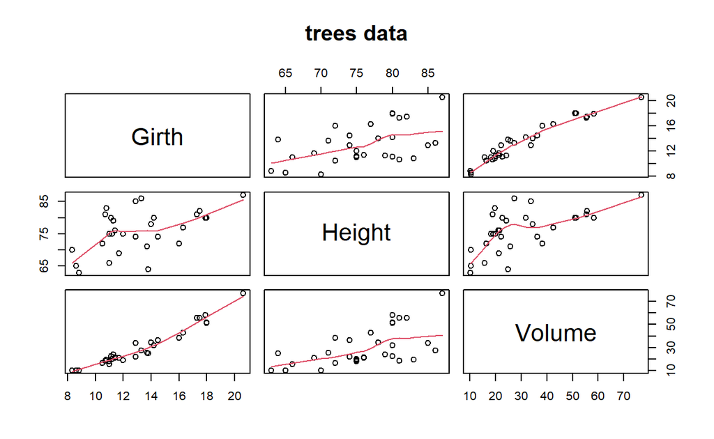

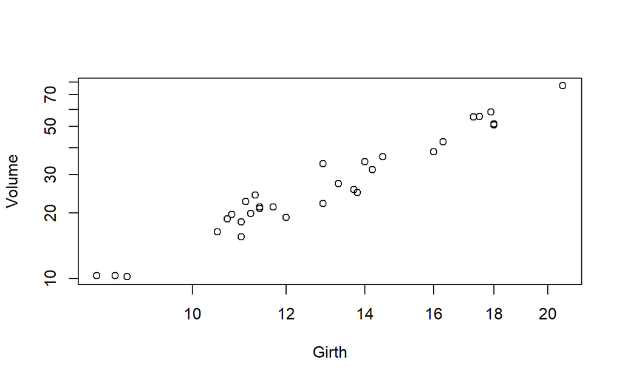

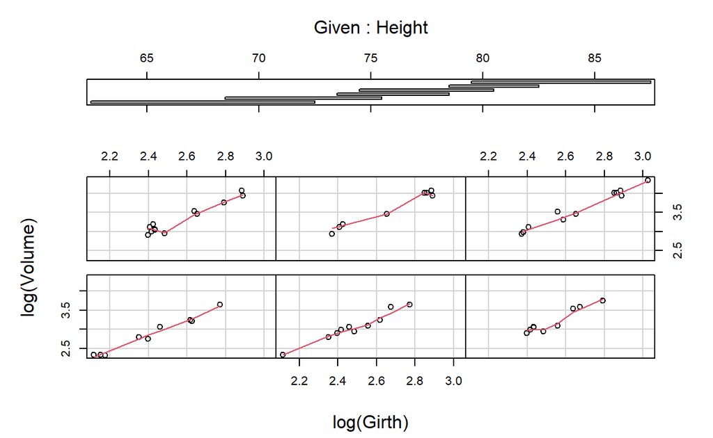

pairs(trees, panel = panel.smooth, main = “trees data”) plot(Volume ~ Girth, data = trees, log = “xy”) coplot(log(Volume) ~ log(Girth) | Height, data = trees,panel = panel.smooth)

#Question 3. In the 2000 election for U.S. president, the counting of votes in Florida was controversial. In Palm Beach County in south Florida, for example, voters used a so-called butterfly ballot. Some believe that the layout of the ballot caused some voters to cast votes for Buchanan when their intended choice was Gore.The data has variables for the number of votes for each candidate—Gore, Bush, and Buchanan. Run a simple linear regression model where the Buchanan vote is the outcome and the Bush vote is the explanatory variable. Produce the regression diagnostic plots. Is Palm Beach County an outlier based on the diagnostic plots? Why or why not?

Simple linear regression model

CODE:

[output not shown]

> summary(lm(Buchanan ~ Bush, data = florida))

CODE:

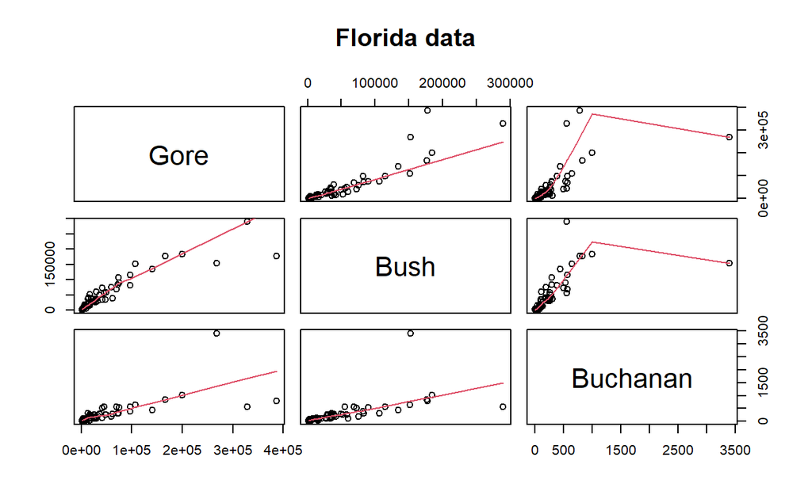

#PART 2 (Final Project)

##1. What is your research question for the final project?

Based on studies conducted in 1986, what percentage of people were working remotely vs those that had to travel for work? How does that compare to the data shared in the same year for the number of hours people were working. Is there any correlation?

##2. What is your hypothesis (i.e. an answer to the research question) that you want to test?

My hypothesis is that I’d like to test is the difference between in time to commute to time worked. I’d like to see if people that don’t travel worked very many hours.

##3. Present some exploratory analysis. In particular:

###a. Numerically summarize (e.g. with the summary() function) the variables of interest (the outcome, the explanatory variable, the control variables).

[output not shown]

###b. Plot the relationships between key variables. You can do this any way you want, but one straightforward way of doing this would be with the pairs() function or other scatter plots / box plots. Interpret what you see.

[output not shown]